# R for Health Data Science

Week 10: Intro to Machine Learning - Classification Trees

Sam Stewart

2021-05-07

```r
library(Hmisc)
library(kableExtra)
library(tidyverse)
library(ggplot2)
library(boomer)
library(XML)
library(car)
library(rpart)
library(rattle)
library(pROC)

#lot's of ML algorithms have randomness, so it's good practice to
#set the seed at the beginning of your work so it will produce consistent
#results
set.seed(11)

dat = read.csv("data/brfss2013-Connecticut.csv")

#variables under study
vars = c('bphigh4','cvdinfr4','cvdcrhd4','cvdstrk3','asthma3','chcscncr','chcocncr',
         'chccopd1','havarth3','addepev2','chckidny','diabete3','drvisits')

dat %>% tibble %>%
  select(vars)
```

```
## # A tibble: 7,710 x 13
##    bphigh4 cvdinfr4 cvdcrhd4 cvdstrk3 asthma3 chcscncr chcocncr chccopd1
##      <int>    <int>    <int>    <int>   <int>    <int>    <int>    <int>
##  1       1        2        2        2       2        2        2        2
##  2       1        2        7        2       2        2        2        2
##  3       1        2        2        2       2        1        2        2
##  4       3        2        2        2       2        2        2        2
##  5       3        2        2        2       2        1        2        2
##  6       3        2        2        2       2        2        2        2
##  7       1        7        2        2       2        2        2        2
##  8       1        2        2        2       2        1        2        2
##  9       3        2        2        2       2        2        2        2
## 10       3        2        2        2       2        2        2        2
## # ... with 7,700 more rows, and 5 more variables: havarth3 <int>,
## #   addepev2 <int>, chckidny <int>, diabete3 <int>, drvisits <int>
```

```r
#dat02 is a new version of the dataset
dat02 = data.frame(ID=rownames(dat))[,-1]

#car::recode is useful for collapsing levels in a factor
#we need the car:: part because dplyr also has a recode function, but it's mor verbose
dat02$bphigh = car::recode(dat$bphigh4, recodes="1=1;2:4=0;else=NA")
dat02$ha = car::recode(dat$cvdinfr4,recodes="1=1;2=0;else=NA")
dat02$chd = car::recode(dat$cvdcrhd4,recodes="1=1;2=0;else=NA")
dat02$stroke = car::recode(dat$cvdstrk3,recodes="1=1;2=0;else=NA")
dat02$asthma = car::recode(dat$asthma3,recodes="1=1;2=0;else=NA")
dat02$skinCa = car::recode(dat$chcscncr,recodes="1=1;2=0;else=NA")
dat02$otherCa = car::recode(dat$chcocncr,recodes="1=1;2=0;else=NA")
dat02$copd = car::recode(dat$chccopd1,recodes="1=1;2=0;else=NA")
dat02$arthritis = car::recode(dat$havarth3,recodes="1=1;2=0;else=NA")
dat02$depression = car::recode(dat$addepev2,recodes="1=1;2=0;else=NA")
dat02$kidney = car::recode(dat$chckidny,recodes="1=1;2=0;else=NA")
dat02$diabetes = car::recode(dat$diabete3,recodes="1=1;2:4=0;else=NA")
#drvisits is continuous so it doesn't need to be recoded
dat02$drvisits = dat$drvisits
dat02$drvisits[which(dat02$drvisits==88)] = 0
dat02$drvisits[which(dat02$drvisits>76)] = NA

#converting to factors in a new dataset
dat03 = do.call(cbind.data.frame,lapply(dat02,factor,levels=1:0,labels=c("Yes","No")))
dat03$drvisits = dat02$drvisits

#dropping missing values from each dataset
dat03 = na.omit(dat03)
dat02 = na.omit(dat02)

#dat02 is the numeric version of the dataset,
#dat03 is the factor version
```

I’ve changed our plan for the last lecture - I was going to talk about XML and JSON data, but they’re a bit too complex from a programming perspective to explore at this point. If you have a need for working with XML data then let me know and I can share some sample code to get you through.

Instead I want to broach the topic of Machine Learning. R is one of the two premier languages being used in the ML world (the other major choice being Python). As a brief introduction I want to talk about how to create and share classification trees - I’ve included a tutorial on how classification trees work from a course on Data Mining I taught, take a look through if you’re more interested. In this tutorial we’ll talk about

1. Training vs Test data
2. Building CART
3. Presenting CART
4. Evaluating CART

# 1 Training and Test Data

Classification is about trying to accurately predict an outcome from a set of predictors. Unlike our regression methods, in classification we’re primarily interested in the accuracy of the prediction - in statistics we tend to be more focused on the *mechanism* of prediction, or the regression coefficients.

In order to have an unbiased evaluation of the model we should evaluate it on data that it was not trained on - evaluating the quality of a prediction based on the data it was trained on would result in *over-fitting*, or a model that is very good for that specific data and very poor outside of it.

There are many complex methods of creating a training/test split (cross-validation, bootstrapping, bagging and boosting), but I’m going to focus on a simple 70/30 split of the data. 70% of the observations will be in the training data, and 30% in the test.

```r
#we'll focus on the factored data
n=dim(dat03)[1]
nSplit = round(n*0.7,0)
train = dat03[1:nSplit,]
test = dat03[(nSplit+1):n,]
```

In our model building we’ll fit on the `train` dataset and then build on the `test` dataset.

The data we’re working with in this lecture is the Behavioral Risk Factor Surveillance System (BRFSS) - “America’s premier system of health-related telephone surveys”. We’ll be focusing on the Connecticut subset, and will be predicting high blood-pressure (`bphigh`) with several predictors. See the data dictionaries here for more details of the variables: https://www.cdc.gov/brfss/annual_data/annual_2013.html.

# 2 RPART

The traditional name for trees is *Classification and Regression Trees*, or CART. The original CART algorithm was copyrighted, so some researchers re-created the algorithm, and implemented it in R as RPART, or *Recursive Partitioning and Regression Trees*.

The idea is to create a decision tree from a flowchart like structure. All the observations start at the top, and then are split into child nodes based on a decision rule. Splitting continues until an endpoint (leaf) is reached, at which point a label is assigned in some manner.

Some important components of the algorithm that I won’t cover in detail

- How do you decide what splits to consider?
- How do you choose the best split?
- How do you decide to stop splitting?

I’ll focus more on the function itself, and direct you toward the important parts for building a tree.

```
rpart(formula, data, weights, subset, na.action = na.rpart, method,
      model = FALSE, x = FALSE, y = TRUE, parms, control, cost, ...)
```

The format is much like in regression - a formula that defines the model, and a dataset.

```r
###a simple classification tree
mod.cart01 = rpart(bphigh~.,data=train)
mod.cart01
```

```
## n= 4943
##
## node), split, n, loss, yval, (yprob)
##       * denotes terminal node
##
##  1) root 4943 1886 No (0.3815497 0.6184503)
##    2) arthritis=Yes 1472  618 Yes (0.5801630 0.4198370) *
##    3) arthritis=No 3471 1032 No (0.2973207 0.7026793)
##      6) diabetes=Yes 256   90 Yes (0.6484375 0.3515625) *
##      7) diabetes=No 3215  866 No (0.2693624 0.7306376)
##       14) chd=Yes 86   22 Yes (0.7441860 0.2558140) *
##       15) chd=No 3129  802 No (0.2563119 0.7436881) *
```

```r
summary(mod.cart01)
```

```
## Call:
## rpart(formula = bphigh ~ ., data = train)
##   n= 4943
##
##           CP nsplit rel error    xerror       xstd
## 1 0.12513256      0 1.0000000 1.0000000 0.01810846
## 2 0.04029692      1 0.8748674 0.8748674 0.01757927
## 3 0.02226935      2 0.8345705 0.8345705 0.01736664
## 4 0.01000000      3 0.8123012 0.8123012 0.01723984
##
## Variable importance
## arthritis  diabetes       chd  drvisits      copd        ha    stroke    kidney
##        57        24        14         1         1         1         1         1
##
## Node number 1: 4943 observations,    complexity param=0.1251326
##   predicted class=No   expected loss=0.3815497  P(node) =1
##     class counts:  1886  3057
##    probabilities: 0.382 0.618
##   left son=2 (1472 obs) right son=3 (3471 obs)
##   Primary splits:
##       arthritis splits as  LR,       improve=165.38300, (0 missing)
##       diabetes  splits as  LR,       improve=134.85450, (0 missing)
##       chd       splits as  LR,       improve= 95.19580, (0 missing)
##       drvisits  < 2.5  to the right, improve= 78.04115, (0 missing)
##       ha        splits as  LR,       improve= 63.06548, (0 missing)
##   Surrogate splits:
##       drvisits < 16.5 to the right, agree=0.709, adj=0.024, (0 split)
##       copd     splits as  LR,       agree=0.709, adj=0.022, (0 split)
##       ha       splits as  LR,       agree=0.707, adj=0.018, (0 split)
##       stroke   splits as  LR,       agree=0.705, adj=0.011, (0 split)
##       kidney   splits as  LR,       agree=0.705, adj=0.010, (0 split)
##
## Node number 2: 1472 observations
##   predicted class=Yes  expected loss=0.419837  P(node) =0.2977949
##     class counts:   854   618
##    probabilities: 0.580 0.420
##
## Node number 3: 3471 observations,    complexity param=0.04029692
##   predicted class=No   expected loss=0.2973207  P(node) =0.7022051
##     class counts:  1032  2439
```

[output cut: 22 more lines]

```
##       drvisits < 1.5  to the right, improve=24.52311, (0 missing)
##       stroke   splits as  LR,       improve=18.31978, (0 missing)
##       copd     splits as  LR,       improve=11.97701, (0 missing)
##   Surrogate splits:
##       ha splits as  LR, agree=0.974, adj=0.012, (0 split)
##
## Node number 14: 86 observations
##   predicted class=Yes  expected loss=0.255814  P(node) =0.01739834
##     class counts:    64    22
##    probabilities: 0.744 0.256
##
## Node number 15: 3129 observations
##   predicted class=No   expected loss=0.2563119  P(node) =0.6330164
##     class counts:   802  2327
##    probabilities: 0.256 0.744
```

You can see that the simple summary is a summary of the tree, and the summary gives a detailed description of each node, including all the splits it considered. We’ll look later at plotting.

The important tree controls are passed as a list to the `control` argument.

- `cp` is the “complexity parameter” - it measures how much improvement is needed for a split to be included in the model.
- `minbucket` controls how small a node can be to be created
- `minsplit` controls how small a node can be to be considered for a split

```r
#trying to build as large a tree as possible
mod.cart02 = rpart(bphigh~.,data=train,control=list(cp=0.0,minbucket=0,minsplit=0))
mod.cart03 = rpart(bphigh~.,data=train,control=list(cp=0.0041,minbucket=1,minsplit=2))
```

## 2.1 Getting Optimal Trees

```r
#getting optimal CP values
printcp(mod.cart02)
```

```
##
## Classification tree:
## rpart(formula = bphigh ~ ., data = train, control = list(cp = 0,
##     minbucket = 0, minsplit = 0))
##
## Variables actually used in tree construction:
##  [1] arthritis  asthma     chd        copd       depression diabetes
##  [7] drvisits   ha         kidney     otherCa    skinCa     stroke
##
## Root node error: 1886/4943 = 0.38155
##
## n= 4943
##
##            CP nsplit rel error  xerror     xstd
## 1  0.12513256      0   1.00000 1.00000 0.018108
```

[output cut: 27 more lines]

What this table shows is the size of the tree for decreasing values of `cp` - as the tolerance for improvement goes down, the tree size goes up. The column we care about is the `xerror` column - that’s a cross-validated measure of error that we want to be as small as possible. The plot below provides a visual representation of that column.

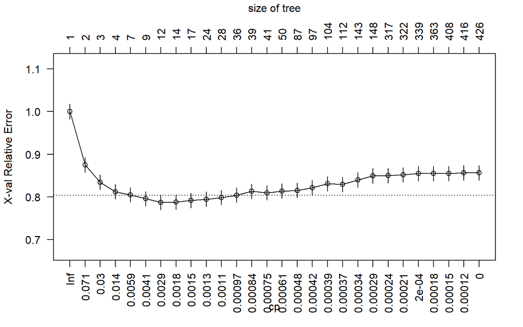

```r
plotcp(mod.cart02,las=2)
```

What we do is find the lowest `xerror` value, then calculate a CI around it. The upper bound of that CI is the lowest reasonable `xerror` we should expect, so we pick the smallest tree that meets that value - in this case it’s at a CP of 0.0041.

Once we’ve identified the appropriate CP value we can either re-fit the tree with the appropriate CP value, or we can *prune* the tree by removing splits below that CP threshold.

```r
#pruning trees is done using prune
mod.cart02a = prune(mod.cart02,cp=0.0005)
mod.cart02b = prune(mod.cart02,cp=0.004)#this should be the same mod.cart03

mod.cart01 = mod.cart02b
```

## 2.2 Plotting

The best thing about CART over other ML algorithms is the ability to understand the decision making process - in that sense it falls somewhere between the explanatory nature of regression and the purely classification goals of Neural Networks and Deep Learning.

Unfortunately the default plotting function for `rpart` objects is terrible, as you can see below. Luckily there is a function `rattle::fancyRpartPlot()` to create usable tree plots.

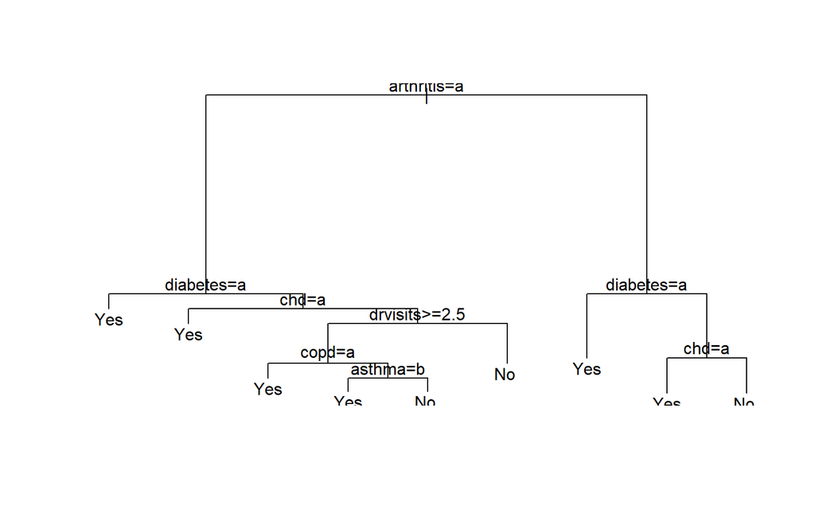

```r
#plotting the trees is best through the rattle library
plot(mod.cart01)#boo :(
text(mod.cart01)
```

[figure not shown]

```r
fancyRpartPlot(mod.cart01)#yay! :)
```

There are three lines to each node by default:

1. The classification of the objects at the node
2. The split between classes at the node
3. The percentage of subjects that reach that node

## 2.3 Evaluation

To evaluate the success of the model we’ll run the test data through it, then compare the predicted results to the actual results. `predict()` will be used to produce the predicted results.

```r
#predicting new values from the model
#default is probabilities
pred.cart01 = predict(mod.cart01,newdata=test)
head(pred.cart01,10)
```

```
##            Yes        No
## 5421 0.2563119 0.7436881
## 5422 0.2563119 0.7436881
## 5423 0.2563119 0.7436881
## 5424 0.2563119 0.7436881
## 5426 0.2563119 0.7436881
## 5428 0.2563119 0.7436881
## 5429 0.2563119 0.7436881
## 5430 0.2563119 0.7436881
## 5432 0.2563119 0.7436881
## 5433 0.2563119 0.7436881
```

```r
pred.cart01 = pred.cart01[,1]#Just keep the Y probabilities
```

You can adjust what is predicted with the `type` argument, but probabilities are the default and are usually the most useful. Since `rpart` can predict multi-level outcomes it produces a prediction for all classes, but in this case we just need the first column.

### 2.3.1 ROC Curve

Once we have the predicted probabilities we’ll evaluate them using a **R**eceiver **O**perator **C**haracteristic curve. There are two libraries that are commonly used to produce ROC curves in R: `ROCR` and `pROC`. I’ll look at `pROC` here, but `ROCR` works fine as well.

```r
roc.cart01 = roc(test$bphigh,pred.cart01,ci=TRUE,levels=c("Yes","No"))
roc.cart01
```

```
##
## Call:
## roc.default(response = test$bphigh, predictor = pred.cart01,     levels = c("Yes", "No"), ci = TRUE)
##
## Data: pred.cart01 in 803 controls (test$bphigh Yes) > 1316 cases (test$bphigh No).
## Area under the curve: 0.6979
## 95% CI: 0.6765-0.7192 (DeLong)
```

```r
roc.dat01 = coords(roc.cart01)
roc.dat01
```

```
##    threshold specificity sensitivity
## 1        Inf  0.00000000   1.0000000
## 2  0.8150599  0.04109589   0.9946809
## 3  0.7694314  0.14694894   0.9802432
## 4  0.7178377  0.17185554   0.9718845
## 5  0.6699634  0.20547945   0.9551672
## 6  0.5960788  0.30261519   0.9361702
## 7  0.4879618  0.48443337   0.8404255
## 8  0.4254443  0.51058531   0.8168693
## 9  0.3374985  0.60273973   0.7477204
## 10      -Inf  1.00000000   0.0000000
```

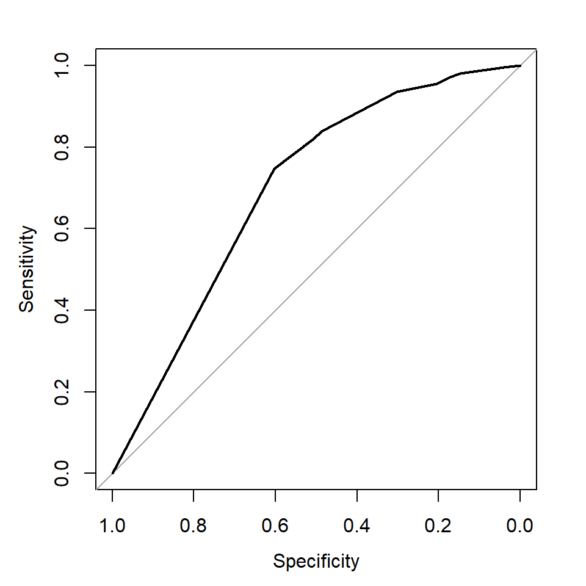

```r
plot(roc.cart01)
```

One nice thing about the `pROC` plot is that it forces the plotting space to be square - ROC curves should always be presented with the x- and y- axes the same length.

We need to convert our predicted probabilities to Y/N values so we can evaluate the model. To do that we’ll use the ‘best’ argument in the `coords()` function to extract the optimal cutpoint - the default is to choose the highest *sens+spec* value, but there are many approaches to this problem.

```r
opt.cart01 = coords(roc.cart01,x='best',transpose=TRUE)
pred.cart01.value = pred.cart01 >= opt.cart01[1]
```

Once we have the predicted Y/N values we can compare them to the actual Y/N values in a 2x2 table, and then calculate a variety of accuracy measures on that table. I’ve included a custom function here that I wrote a while ago called `getAccuracy()` that is a *very fragile* way to get the sens/spec and other numbers - make very sure your table is oriented the right way for the function to work (see the comment).

```r
#a function to get the accuracy of the model from the predicted labels, should be of the form
#           pred=Y  pred=N
#label  Yes      a       b
#        No      c       d
getAccuracy = function(tab){
    if(any(c(colnames(tab)[1],rownames(tab)[1])%in%c("No",0,FALSE)))
        warning("Are you sure that your table is set up the right way?")
    TP = tab[1,1]
    FP = tab[2,1]
    FN = tab[1,2]
    TN = tab[2,2]
    P = rowSums(tab)[1]
    N = rowSums(tab)[2]
    acc=(TP+TN)/(P+N)
    errRate=(FP+FN)/(P+N)
    sens=TP/P
    spec=TN/N
    prec=TP/(TP+FP)
    F1=2*prec*sens/(prec+sens)
    F2=(1+2^2)*prec*sens/(2^2*prec+sens)
    F0.5=(1+0.5^2)*prec*sens/(0.5^2*prec+sens)
    out=c(acc,errRate,sens,spec,prec,F1,F2,F0.5)
    names(out) = c('acc','errRate','sens','spec','prec','F1','F2','F0.5')
    out
}

#Note that I have to flip the columns to make the diagonal line up right
tab.cart01 = table(test$bphigh,pred.cart01.value)[,2:1]
tab.cart01
```

```
##      pred.cart01.value
##       TRUE FALSE
##   Yes  484   319
##   No   332   984
```

```r
getAccuracy(tab.cart01)
```

```
##       acc   errRate      sens      spec      prec        F1        F2      F0.5
## 0.6927796 0.3072204 0.6027397 0.7477204 0.5931373 0.5978999 0.6007944 0.5950332
```

# 3 Breakout Activity

We’re going back to the Framingham data to see how well we can predict smoking status. Build a CART model predicting smoking status - use whatever variables you see fit. I’ll start everyone off with the same training/test split.

```r
fram = read.csv("data/framinghamFirst.csv",header=TRUE,
               na.strings=".",stringsAsFactors=FALSE)
fram = fram %>%
  select(-CIGPDAY) #we obviously need to drop this

#any data formatting you should do here first
set.seed(42)
n=dim(fram)[1]
nSplit = round(n*0.7,0)
train.fram = fram[1:nSplit,]
test.fram = fram[(nSplit+1):n,]
```